# Análisis de Siniestralidad Vial en Palmira

Santiago Vera - Ricardo Salazar - Daniel Puentes

2025-07-20

# 1. Contexto y Objetivos del Análisis

La siniestralidad vial es un problema de salud pública y seguridad en muchas ciudades. Analizar los datos históricos de accidentes en el municipio de Palmira nos permite identificar patrones espaciales y demográficos, que son cruciales para el diseño de políticas de prevención, la optimización de recursos de emergencia y la mejora de la infraestructura vial.

Este análisis busca explorar la distribución de los siniestros viales reportados en Palmira para identificar zonas de alta concentración y entender las características principales de estos eventos.

## Pregunta de Interés

Estudiar el fenómeno de accidentalidad en Palmira de manera que a través de las técnicas de patrones puntuales se puedan identificar patrones espaciales significativos, y determinar si la distribución de los accidentes es aleatoria o sigue un patrón específico.

# 2. Carga y Limpieza de Datos

```r
library(sf)
library(terra)
library(dplyr)
library(mapview)
library(ggplot2)
library(viridis)
library(spatstat)
library(kableExtra)
```

Los datos crudos provienen de un csv y es crucial realizar dos pasos de limpieza cruciales para continuar con el análisis:

- **Corregir Coordenadas:** Las columnas LAT y LONG vienen como texto con un formato incorrecto. Se convierten a un formato numérico válido.
- **Eliminar Datos Inválidos:** Se descarta cualquier fila que no tenga coordenadas después de la limpieza.

```r
db <- read.csv("Siniestros_Viales_Palmira_20250720.csv")

# Corregir formato de longitud (LONG)
db$LONG <- gsub("\\.", "", db$LONG)
db$LONG <- as.numeric(db$LONG) / 100000
# Corregir formato de latitud (LAT)
db$LAT <- as.numeric(db$LAT) / 100
# Eliminar filas con coordenadas NA
db <- db[!is.na(db$LONG) & !is.na(db$LAT), ]

db <- db[-c(1394, 1329, 1340, 1392) ,]

# Eliminar elemento de IPAT
db <- db[!db$IPAT == "8709", ]

db <- db[!db$ZONA == "RURAL", ]
```

# 3. Creación del Objeto Espacial

Se convierte el data frame en un objeto espacial de tipo sf

```r
accidentes_vect <- st_as_sf(db,
                                coords = c("LONG", "LAT"),
                                crs = 4326)
```

# 4. Analisis Exploratorio

Teniendo el objeto espacial, el primer paso es visualizarlo para entender como se distribuyen los datos

```r
shp_path <- "Antioquia/MGN_ADM_MPIO_GRAFICO.shp"
municipios <- st_read(shp_path, quiet = TRUE)
Palmira_mapa <- filter(municipios, mpio_cnmbr == "PALMIRA")
```

```r
shp_path2 <- "palmi/MGN_URB_AREA_CENSAL.shp"
municipios2 <- st_read(shp_path2, quiet = TRUE)
Palmira_mapa2 <- filter(municipios2, COD_MPIO == "76520" & NOM_CPOB == "PALMIRA")
```

```r
shp_path3 <- "red_vial_palmira/red_vial_palmira.shp"
vias <- st_read(shp_path3, quiet = TRUE)
```

## 4.1 Mapa Interactivo

Usamos mapview para una visualización rápida e interactiva. Cada punto se colorea según la CLASE.SINIESTRO, asi se puede interactuar de forma sencilla y ver sus atributos

```r
mapview(accidentes_vect, zcol = "CLASE.SINIESTRO",
        legend = TRUE,
        layer.name = "Accidentes Viales")
```

[interactive chart not shown]

Frecuencia de Siniestros por Clase en Palmira

| Clase de Siniestro | Número de Casos |
| --- | --- |
| ATROPELLO | 69 |
| CAIDA DE ARBOL | 2 |
| CHOQUE | 1391 |
| CHOQUE OBJETO FIJO ARBOL | 4 |
| CHOQUE OBJETO FIJO POSTE | 7 |
| CHOQUE OBJETO FIJO SARDINEL | 6 |
| CHOQUE TACHA | 1 |
| CHOQUE VEHICULO ESTACIONADO | 3 |
| CHOQUEOBJETO FIJO INMUEBLE | 3 |
| PEATON | 1 |
| VOLCAMIENTO | 18 |

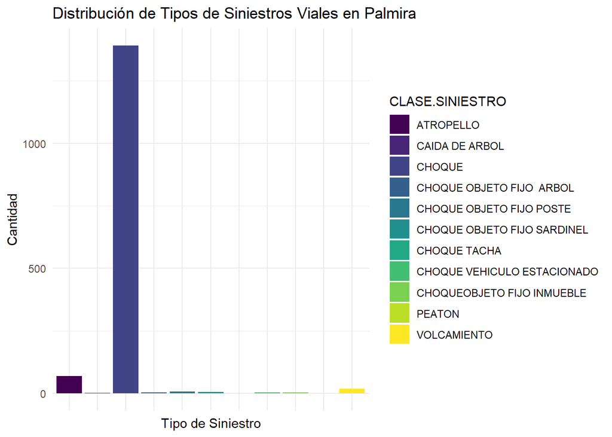

```r
ggplot(accidentes_vect) +
  geom_bar(aes(x = CLASE.SINIESTRO, fill = CLASE.SINIESTRO)) +
  labs(title = "Distribución de Tipos de Siniestros Viales en Palmira",
       x = "Tipo de Siniestro", y = "Cantidad") +
  scale_fill_viridis_d() +
  theme_minimal() +
  theme(axis.text.x = element_blank())
```

### 5. Análisis y Manipulación de Datos

### 5.1 Filtrado de Datos por Tipo de Siniestro

#### Choque

Se filta el conjunto de datos para analizar un subgrupo, en este caso, únicamente los siniestros clasificados como “CHOQUE”

```r
choques_sf <- accidentes_vect %>%
  filter(CLASE.SINIESTRO == "CHOQUE")
```

```r
ventana_corte <- st_as_sfc(st_bbox(choques_sf))

Palmira_recortada <- st_intersection(Palmira_mapa, ventana_corte)
puntos_dentro <- choques_sf[st_within(choques_sf, Palmira_mapa, sparse=FALSE),]

puntos_validos <- choques_sf[st_intersects(choques_sf, Palmira_recortada, sparse=FALSE),]
```

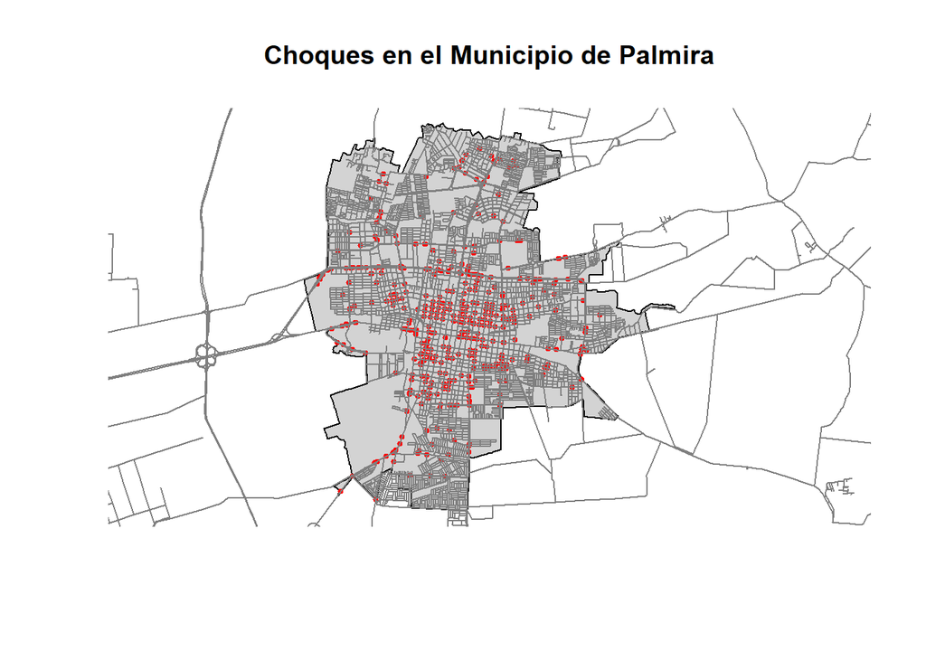

```r
# Polígono base
plot(st_geometry(Palmira_mapa2), col = "lightgray", main = "Choques en el Municipio de Palmira")

plot(st_geometry(puntos_dentro), col = "red", pch = 19, cex = .5, add=TRUE)

plot(st_geometry(vias),
     col = "gray50",
     add = TRUE)
```

El Parque Nacional Natural Las Hermosas está ubicado al este de Palmira y representa una zona protegida nacional, por ende se decide recortar el área de estudio para evitar incluir en el mapa el área protegida.

#### Atropello

Ahora, se realiza un procedimiento similar pero segregando por la clase de siniestro “Atropello”

```r
atropello_sf <- accidentes_vect %>%
  filter(CLASE.SINIESTRO == "ATROPELLO")

puntos_dentro_recortado_a <- atropello_sf[st_within(atropello_sf, Palmira_mapa2, sparse=FALSE),]
```

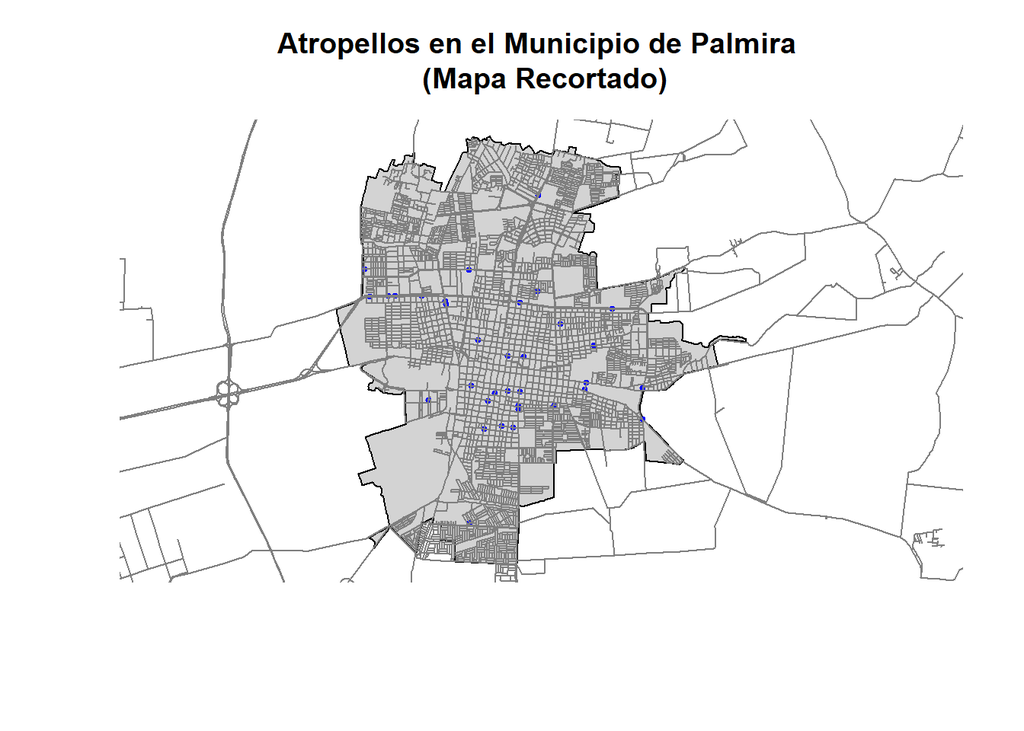

```r
plot(st_geometry(Palmira_mapa2), col = "lightgray", main = "Atropellos en el Municipio de Palmira \n (Mapa Recortado)")

plot(st_geometry(puntos_dentro_recortado_a), col = "blue", pch = 19, cex = .5, add=TRUE)

plot(st_geometry(vias),
     col = "gray50",
     add = TRUE)
```

# 6. Análisis de Patrones de Puntos (PPA)

Ahora, se quiere analizar si la distribución espacial de los accidentes es aleatoria o si sigue un patrón

## 6.1 Preparación de Datos para PPA

Los análisis de patrones espaciales requieren mediciones de distancia en unidades métricas (como metros), no en grados. Por lo tanto, es necesario transformar los datos a un sistema de coordenadas proyectado.

Primero, filtramos el conjunto de datos para enfocarnos en los siniestros de mayor frecuencia: choques y atropellos. A continuación, proyectamos tanto estos puntos como el polígono del borde de Palmira al sistema MAGNA-SIRGAS (EPSG:3116). Esto asegura que todas las geometrías sean compatibles y estén expresadas en metros.

Subconjunto de dos tipos de siniestros

```r
accidentes_seleccionados <- accidentes_vect %>%
  filter(CLASE.SINIESTRO == "CHOQUE" | CLASE.SINIESTRO == "ATROPELLO")
```

Transformar el sistema de coordenadas

```r
accidentes_seleccionados_proy <- st_transform(accidentes_seleccionados, crs = 3116)

# Verificamos la geometría proyectada
st_geometry(accidentes_seleccionados_proy)
```

```
## Geometry set for 1460 features
## Geometry type: POINT
## Dimension:     XY
## Bounding box:  xmin: 741112.6 ymin: 879285.8 xmax: 755767.8 ymax: 887934.2
## Projected CRS: MAGNA-SIRGAS / Colombia Bogota zone
## First 5 geometries:
```

```
## POINT (752549.8 881104.4)
## POINT (752549.8 881104.4)
```

```
## POINT (754148.6 883353.7)
## POINT (754148.6 883353.7)
## POINT (754148.6 883353.7)
```

Para generar puntos, necesitamos un polígono de borde para Palmira.

```r
Palmira_mapa_proy <- st_transform(Palmira_mapa2,
                                  crs = st_crs(accidentes_seleccionados_proy))

palmira_borde <- st_geometry(Palmira_mapa_proy)
```

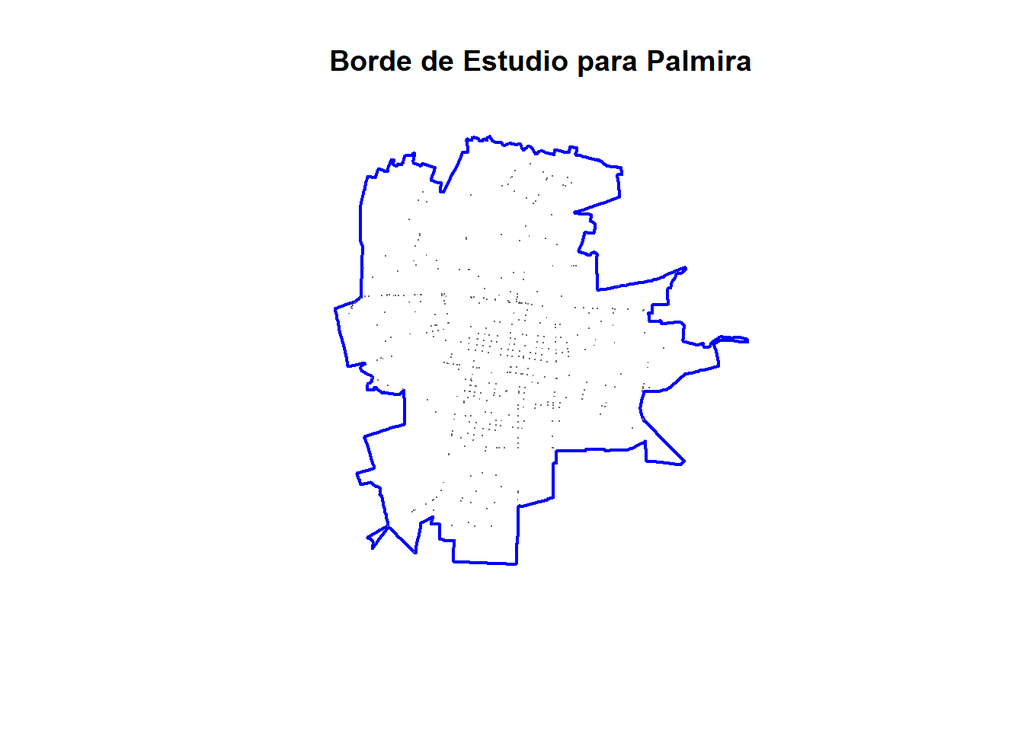

```r
plot(st_geometry(palmira_borde), main = "Borde de Estudio para Palmira", border = "blue", lwd = 2)
plot(st_geometry(accidentes_seleccionados_proy), add = TRUE, pch = ".", col = "grey40")
```

## 6.2 Creación del Objeto PPP

Para utilizar las herramientas de spatstat, es necesario estructurar los datos en un formato especial de patrón de puntos (ppp). Este objeto encapsula tanto las coordenadas de los eventos como el polígono exacto del área de estudio (conocido como ventana de observación, owin).

A continuación, crearemos dos patrones de puntos clave para nuestro análisis: uno con la ubicación de los siniestros reales (ppp_accidentes) y otro con un conjunto de puntos simulados de forma aleatoria (ppp_random). Este último nos servirá como un modelo de referencia de Completa Aleatoriedad Espacial (CSR) para poder compararlo con nuestro patrón observado.

```r
bbox <- st_bbox(palmira_borde)
xmin <- bbox["xmin"]
ymin <- bbox["ymin"]
xmax <- bbox["xmax"]
ymax <- bbox["ymax"]
```

Se generan un número de puntos aleatorios dentro del polígono de Palmira para comparar con los puntos reales de accidentes.

```r
set.seed(1913)
puntos_aleatorios <- data.frame(
  x = runif(n = nrow(accidentes_seleccionados_proy), min = bbox["xmin"], max = bbox["xmax"]),
  y = runif(n = nrow(accidentes_seleccionados_proy), min = bbox["ymin"], max = bbox["ymax"])
)

win_palmira <- as.owin(palmira_borde) # Definir la ventana

# Objeto ppp para los accidentes reales
ppp_accidentes <- ppp(
  x = st_coordinates(accidentes_seleccionados_proy)[, 1],
  y = st_coordinates(accidentes_seleccionados_proy)[, 2],
  window = win_palmira
)

ppp_accidentes <- as.ppp(ppp_accidentes)

# Objeto ppp para los puntos aleatorios
ppp_random <- ppp(x = puntos_aleatorios$x, y = puntos_aleatorios$y, window = win_palmira)

ppp_random <- as.ppp(ppp_random)
```

## 6.3. Prueba de Hipótesis con Cuadrantes (Quadrat Test)

Una primera aproximación para evaluar la aleatoriedad es la prueba de cuadrantes. Este método divide el área de estudio en una grilla de celdas y utiliza una prueba de Chi-cuadrado para comparar la cantidad de puntos observados en cada celda con la cantidad que se esperaría si el patrón fuera completamente aleatorio.

La hipótesis nula y alternativa para la prueba de cuadrantes son las siguientes:

$$H_0: \text{La distribución de los puntos
es aleatoria.} \\ H_1: \text{La distribución de los puntos no es
aleatoria.}$$

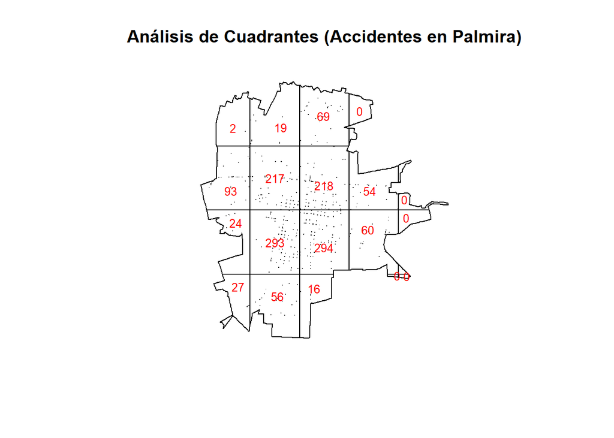

```r
qc_accidentes <- quadratcount(ppp_accidentes, nx = 5, ny = 4)

plot(ppp_accidentes, pch = ".", main = "Análisis de Cuadrantes (Accidentes en Palmira)")
plot(qc_accidentes, add = TRUE, textargs = list(col = "red", cex = 0.8))
```

```r
quadrat.test(qc_accidentes)
```

```
##
##  Chi-squared test of CSR using quadrat counts
##
## data:
## X2 = 862.85, df = 18, p-value < 2.2e-16
## alternative hypothesis: two.sided
##
## Quadrats: 19 tiles (irregular windows)
```

El resultado de la prueba es estadísticamente significativo, lo que nos lleva a rechazar la hipótesis nula de completa aleatoriedad espacial. Esto confirma que la distribución de choques y atropellos en Palmira no es producto del azar, sino que sigue un patrón espacial definido.

## 6.4 Análisis de la Intensidad del Proceso

Tras rechazar la hipótesis de aleatoriedad, el siguiente paso es caracterizar la intensidad del proceso. Dado que los puntos no se distribuyen de manera uniforme, la intensidad, o el número esperado de puntos por unidad de área, no es constante. Utilizaremos métodos no paramétricos para estimar esta intensidad variable y visualizar las zonas de alta y baja concentración de accidentes.

### 6.4.1 Selección del Ancho de Banda (Sigma)

La estimación de intensidad por kernels depende críticamente de un parámetro de suavizado (sigma o ancho de banda). Antes de visualizar el mapa final, es útil conocer el valor de sigma que spatstat selecciona por defecto, el cual se basa en la dispersión de los puntos.

```r
xx <- density(ppp_accidentes)
attr(xx,"sigma")
```

```
## [1] 821.306
```

### 6.4.2 Estimación de Densidad por Kernels (Regla de Scott)

Para crear un mapa de riesgo visual, se emplea la estimación de densidad por kernels. Este método no paramétrico genera una superficie suave que representa la intensidad estimada de accidentes. Para este análisis inicial, se utiliza la regla de Scott (bw.scott.iso), un método automático y robusto para seleccionar el ancho de banda. El mapa resultante permite identificar visualmente los puntos calientes de siniestralidad.

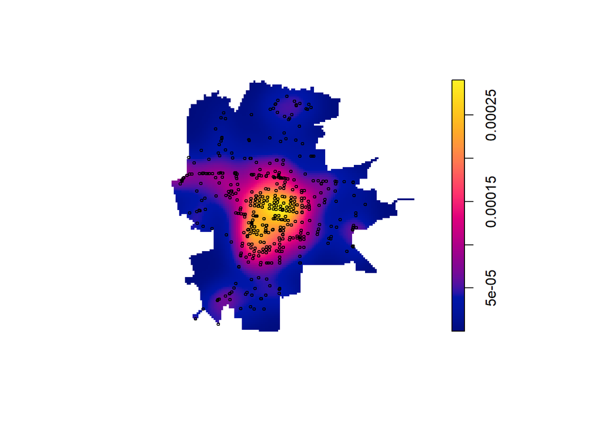

```r
plot(density(ppp_accidentes, sigma = bw.scott.iso(ppp_accidentes)),
     main = "Densidad de Accidentes Viales en Palmira")
points(ppp_accidentes, cex = .5)
```

## 6.5. Análisis de Correlación Espacial (Segundo Orden)

Ahora que tenemos una idea de la intensidad variable, queremos investigar la interacción entre los puntos. Es decir, ¿la presencia de un accidente hace más o menos probable la ocurrencia de otro en sus cercanías, incluso después de tener en cuenta que hay zonas de alto riesgo? Para esto se utilizan las características de segundo orden.

### 6.5.1 Función K Inhomogénea

La función K inhomogénea es la herramienta adecuada para este análisis. Compara la estructura de nuestros datos (línea negra) con la de un proceso aleatorio cuya intensidad varía espacialmente de la misma forma que nuestros datos (línea roja).

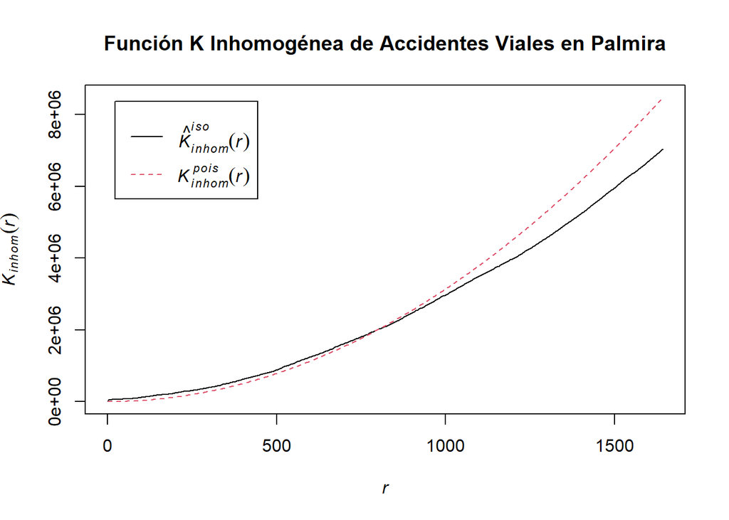

```r
yy <- Kinhom(ppp_accidentes, correction = "isotropic")

plot(yy, main = "Función K Inhomogénea de Accidentes Viales en Palmira")
```

### 6.5.2 Prueba de Hipótesis con Envolventes Globales

Una inspección visual no es suficiente para una conclusión estadística. La prueba de la envolvente global formaliza este análisis. Se simulan múltiples patrones bajo la hipótesis nula (un proceso de Poisson inhomogéneo) para crear una banda de confianza. Si la curva de nuestros datos se sale de esta banda, el resultado es estadísticamente significativo.

```r
E <- envelope(ppp_accidentes, Kinhom, nsim = 99, nrank = 1, savefuns = TRUE, global = TRUE, use.theory = TRUE)
```

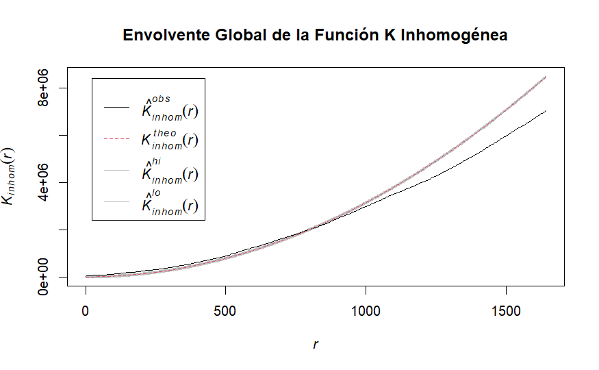

### 6.5.3. Función de Correlación por Pares Inhomogénea

Como complemento a la función K, se analiza la función de correlación por pares inhomogénea. A diferencia de la función K que es acumulativa, la $g(r)$ mide la probabilidad de encontrar un par de puntos exactamente a una distancia r. Es más sensible a las interacciones a escalas de distancia específicas.

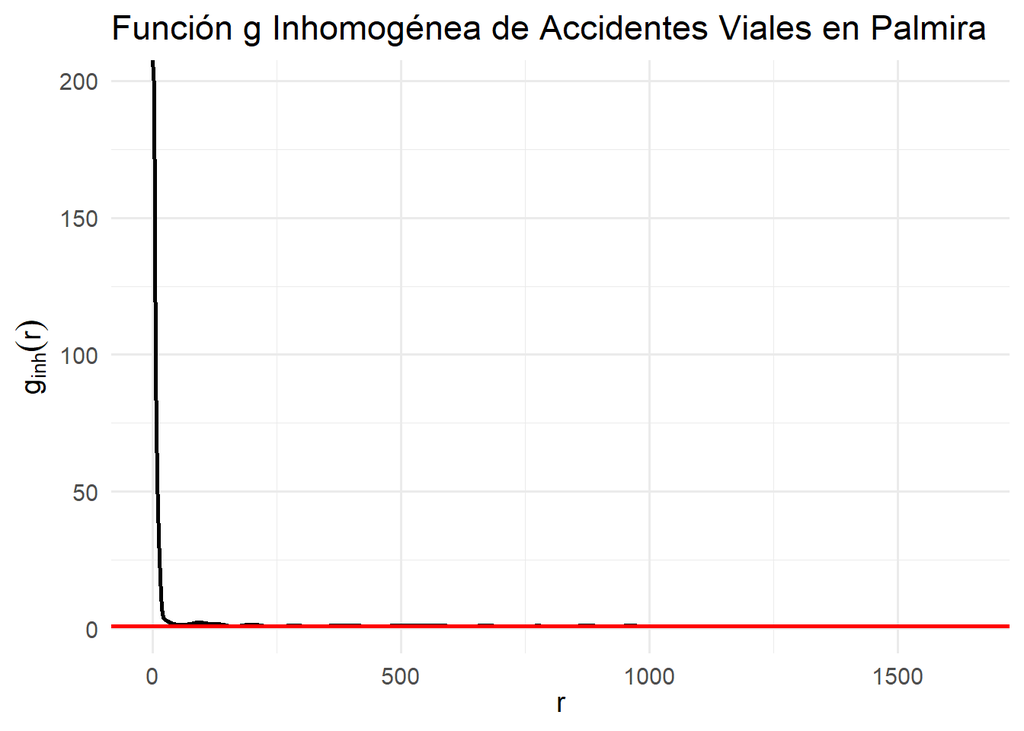

```r
g_inh <- pcfinhom(ppp_accidentes, correction = "translate")
df_ginh <- as.data.frame(g_inh)

ggplot(df_ginh, aes(x = r)) +
  geom_line(aes(y = trans), color = "black", linewidth = 1) +
  geom_hline(yintercept = 1, color = "red", linewidth = 1) +
  labs(x = expression(r), y = expression(g[inh](r))) +
  ggtitle("Función g Inhomogénea de Accidentes Viales en Palmira") +
  theme_minimal(base_size=14)
```

# 7. Conclusiones

El objetivo inicial era estudiar el fenómeno de accidentalidad en Palmira para identificar patrones espaciales significativos y determinar si su distribución era aleatoria o seguía un patrón específico. El análisis realizado permite responder a esta pregunta de manera concluyente.